# Time series graphics

8. `aus_retail`

```r
set.seed(451)
aus_retail_sample <- aus_retail %>%
  filter(`Series ID` == sample(aus_retail$`Series ID`, 1))
```

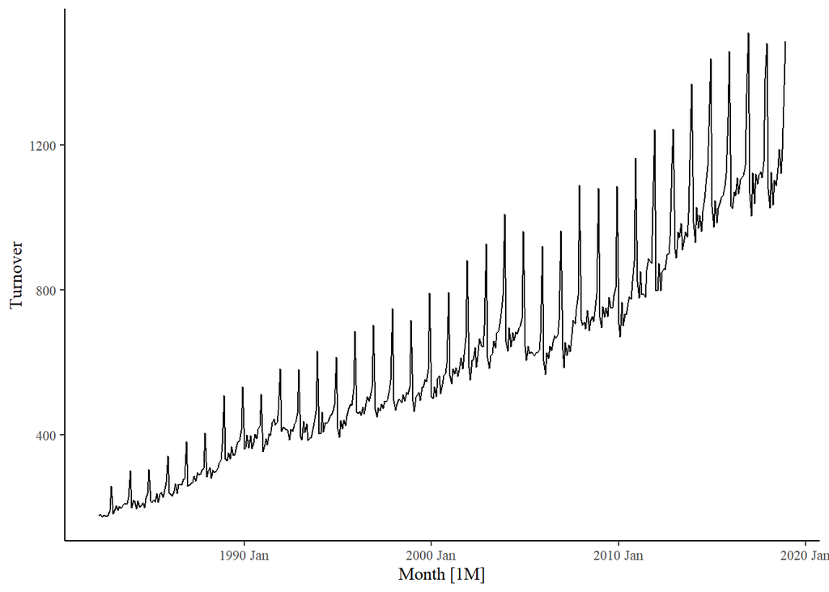

```r
aus_retail_sample %>%
  autoplot(Turnover)
```

Increasing turnover, alright. There is seasonality and an inrceasing trend, but there does not seem to be significant cyclicity.

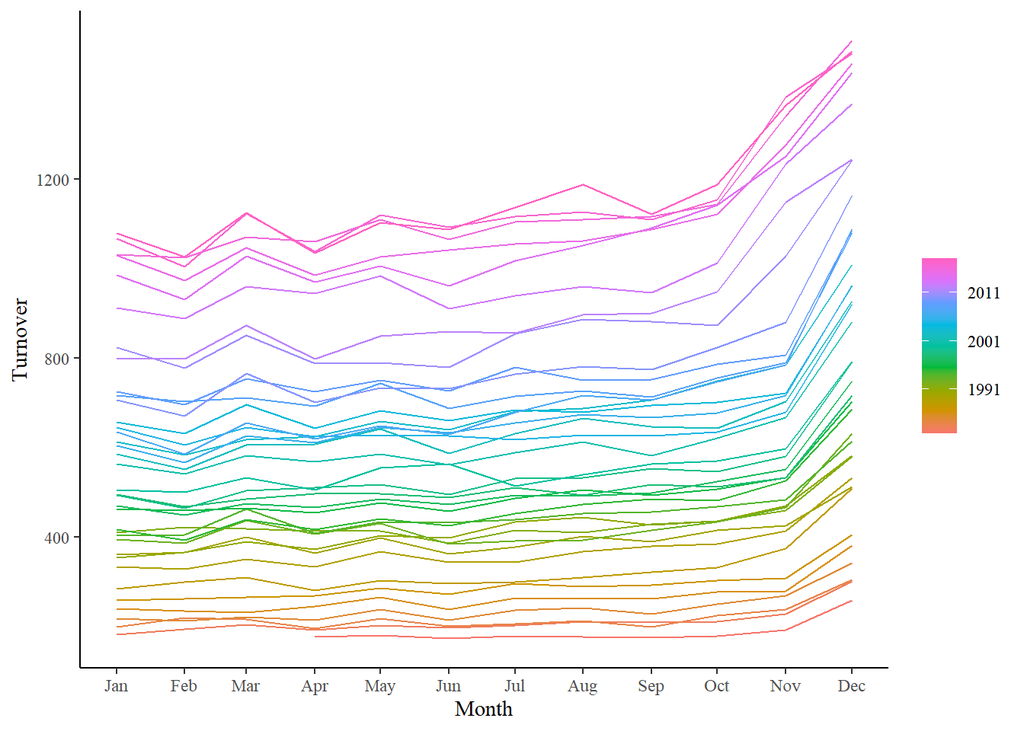

```r
aus_retail_sample %>%
  gg_season(Turnover)
```

It gets noticeably higher in November & December. Also in March, and sometimes during the summer?

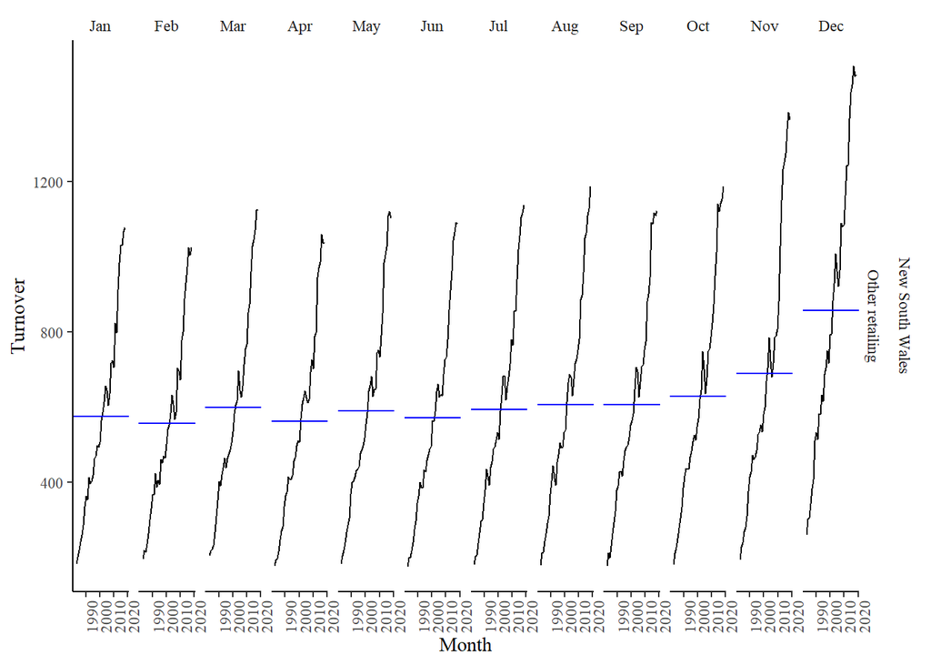

```r
aus_retail_sample %>%
  gg_subseries(Turnover)
```

Same observation.

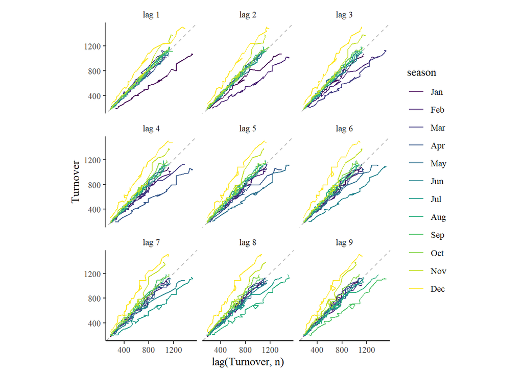

```r
aus_retail_sample %>%
  gg_lag(Turnover)
```

Same observation as before : December has the highest turnover, compared to every other month.

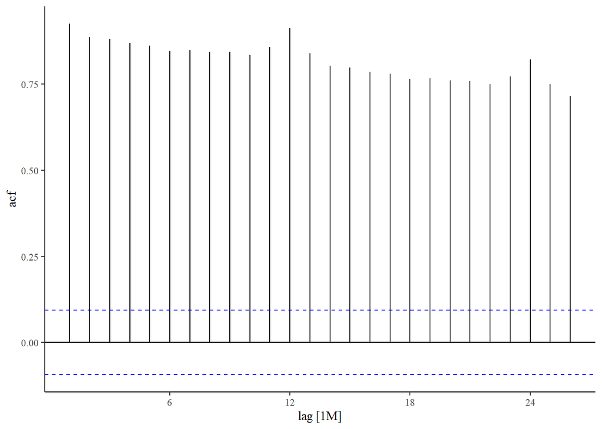

```r
aus_retail_sample %>%
  ACF(Turnover) %>%
  autoplot()
```

Unsurprisingly, there is (very) significant positive autocorrelation.

12. Google

```r
dgoog <- gafa_stock %>%
  filter(Symbol == "GOOG", year(Date) >= 2018) %>%
  mutate(trading_day = row_number()) %>%
  update_tsibble(index = trading_day, regular = TRUE) %>%
  mutate(diff = difference(Close))
```

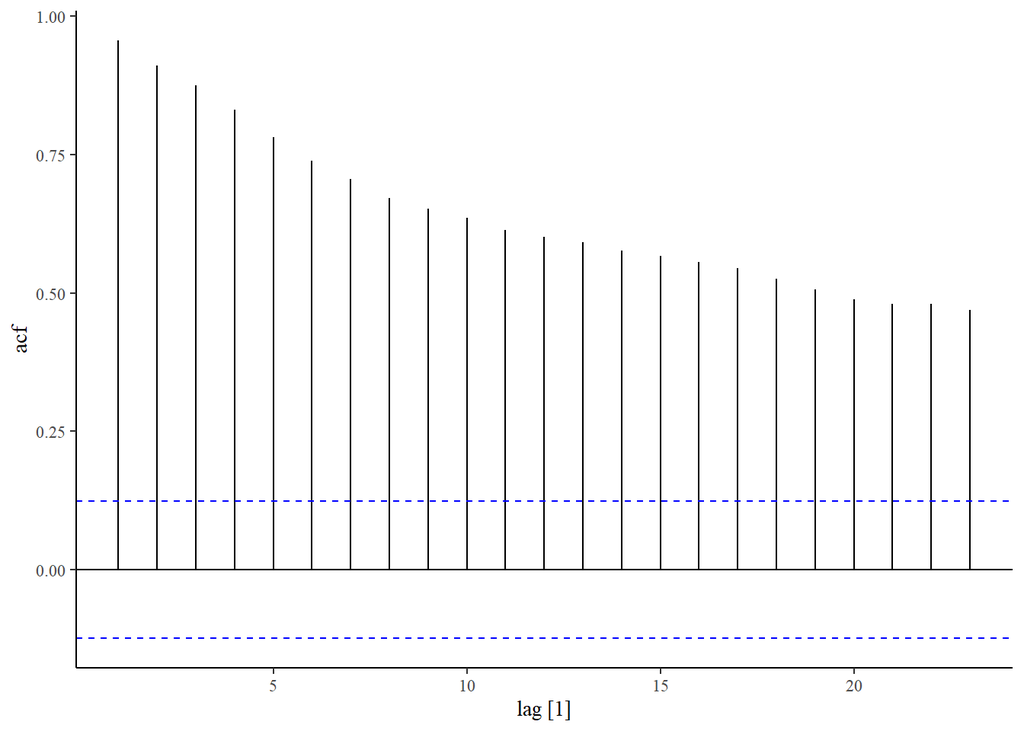

```r
dgoog %>%
  ACF(Close) %>%
  autoplot()
```

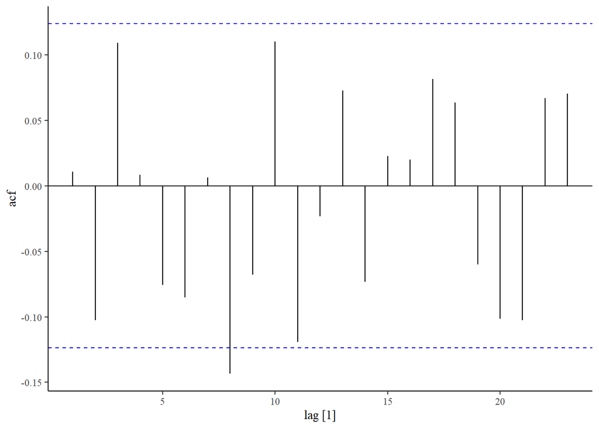

```r
dgoog %>%
  ACF(diff) %>%
  autoplot()
```

It does seem to be white noise.